# 第2回 指数計算と対数計算

経済学基礎数学II

第2回

指数計算と対数計算

指数・対数の定義と計算方法

経済学基礎数学II

第2回 — Topic01

指数法則

かけ算を肩の足し算にする

## 第2回の道のり

1

指数法則

2

対数

3

3 つの法則

4

底をそろえる

✎

ドリル2

いまココ — 指数を思い出して、肩を広げる

## 前回の振り返り

前回のポイント — 第1回「関数と 1 変数の微分」

Q: 利潤が最大になる個数を、どう見つけた

- **限界費用**: 費用 $C(q)$ を微分した $C'(q)$
- **てっぺん**: 利潤の山のてっぺんは、傾きが $0$
- **利潤最大**: 値段 ＝ 限界費用。例では $q = 10$ 個

第2回は微分をいったん置いて、**指数と対数**という道具を作る

## このトピックで学ぶこと

- **$a^n$ の名前**：底・指数（肩）・累乗の言い方をそろえる
- **指数法則 $3$ 本**：かけ算は肩を足す、が主役
- **失敗例**：肩を配れるのは、かけ算の相手だけ
- **肩を広げる**：$0$ 乗・負の肩・分数の肩を、法則から決める

ここで指数がそろえば、次のトピックで「肩を求める問い」に進める

## 累乗 $a^n$ の底と指数

用語

$a^n$ は「$a$ を $n$ 回かけた数」。$a$ が**底**、$n$ が**指数**、$a^n$ 全体が**累乗**

- **読み方**：$a^n$ は「**エーの エヌ乗**」。$2^3$ は「ニの サンジョウ」
- **底 $a$**：かける数。$2^3$ なら $2$
- **指数 $n$**：何回かけるか。$2^3$ なら $3$。右上の小さい数を**肩**と呼ぶ
- **累乗 $a^n$**：かけた結果。$2^3 = 8$

以下、**肩**と言ったら指数のこと。$2^3$ の肩は $3$

## $2^n$ と $3^n$ の伸び方

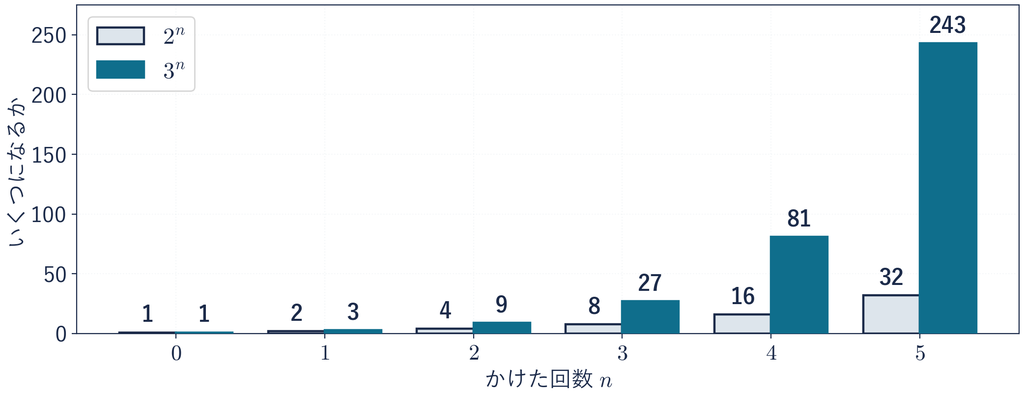

底が変われば伸び方も変わる。肩が $1$ 増えるごとに、底の倍

## 指数法則の狙い

ここから**指数法則**を思い出す。長いかけ算を、肩の計算で片づける道具

- **何を**：同じ底の累乗のかけ算を、肩の足し算に変える
- **いつ要るか**：$2^3 \times 2^2$ のように、底が同じ累乗が並んだとき
- **なぜ今か**：この回であとに出る**対数**の法則は、全部この裏返し

指数法則が無いと、対数の計算は始まらない

## 指数法則 $3$ 本

公式 — 指数法則 $3$ 本

$$a^n a^m = a^{n+m} \quad (a^n)^m = a^{nm} \quad (ab)^n = a^n b^n \quad (a, b > 0)$$

- **一本目**：同じ底のかけ算は、肩を足す。**この回の主役**
- **二本目**：肩の肩は、肩どうしのかけ算
- **三本目**：肩を配れるのは、**かけ算の相手だけ**

三本とも「$a$ を $n$ 回かける」を書き直しただけ。覚えるのはこの $3$ 本

## 指数法則 $3$ 本の数値例

| 式 | ことば | 数で確かめ |
| --- | --- | --- |
| $a^n a^m = a^{n+m}$ | かけ算は肩を足す | $2^3 \times 2^2 = 2^5 = 32$ |
| $(a^n)^m = a^{nm}$ | 肩の肩はかけ算 | $(2^5)^3 = 2^{15}$ |
| $(ab)^n = a^n b^n$ | かけ算なら、 肩を両方に配れる | $(2 \times 3)^2 = 2^2 \times 3^2 = 4 \times 9 = 36$ |

**一本目がこの回の主役**。かけ算が、肩の上では足し算になっている

## 一本目の図解

[figure not shown]

肩を足すだけで答えが合う

## ⚠ 三本目の失敗例

✕ 足し算にも肩を配る

$(2 + 3)^2 = 2^2 + 3^2 = 13$

かけ算がばらせたので、  
足し算もばらせそうに見える

○ 先に足してから肩に乗せる

$(2 + 3)^2 = 5^2 = 25$

配れるのは $(2 \times 3)^2 = 2^2 \times 3^2$  
のかけ算だけ

$13$ と $25$。合わない。**肩を配れるのは、かけ算の相手だけ**

## 指数の拡張

[figure not shown]

「決めた」のであって「証明した」のではない。$a > 0$ で考える

## $0$ 乗と負の肩の一般形

決め方 — $0$ 乗と負の肩

$$a^{0} = 1 \qquad a^{-n} = \frac{1}{a^{n}} \qquad (a > 0)$$

- **読み方**：$a^{-n}$ は「**エーの マイナス エヌ乗**」
- **$a^0$ の理由**：肩が $1$ 減るごとに $\div a$。$a^1 = a$ の次の段が $a^0 = 1$
- **$a^{-n}$ の理由**：同じ $\div a$ をもう一段下へ延ばした値
- **法則が守られる**：$a^{n} \times a^{-n} = a^{0} = 1$

## ⚠ マイナスの肩の読み違い

✕ マイナスを値に付ける

$2^{-2} = -4$

肩のマイナスを  
「答えを負にする印」  
と読んでしまう

○ マイナスの肩は「逆数」の印

$2^{-2} = \frac{1}{2^2} = \frac{1}{4}$

$\div 2$ のはしごを下へ延ばした値。  
正のまま小さくなる

$a > 0$ なら $a^n$ はいつも正。**肩のマイナスは、割る印**

## $a^{1/2}$ が $\sqrt{a}$ になる理由

決め方 — 分数の肩

$a^{1/n} = \sqrt[n]{a}$（$n$ 回かけて $a$ になる数・$a > 0$）  
と決める。とくに $a^{1/2} = \sqrt{a}$

$9^{1/2} \times 9^{1/2}$

$= 9^{\frac{1}{2} + \frac{1}{2}}$

一本目「かけ算は肩を足す」を守る

$= 9^{1} = 9$

肩の $1$ は、そのままの数

$9^{1/2}$

$= \sqrt{9} = 3$

$2$ 回かけて $9$ になる数は $3$

根号は新しい記号ではない。**$\frac{1}{2}$ 乗の別の書き方**

← 一本目「かけ算は肩を足す」を守る

← 肩の $1$ は、そのままの数

← $2$ 回かけて $9$ になる数は $3$

## $\frac{1}{2}$ 乗のはしご

[figure not shown]

$\times 3$ を $2$ 回で $\times 9$。肩の $\frac{1}{2}$ は、その $1$ 回ぶん

## 分数の肩と根号

$n$ 回かけて $a$ になる数が $a^{1/n}$（$a > 0$）。法則を壊さないように決めた

| 肩 | 何回かけて $a$ になるか | 数で確かめ |
| --- | --- | --- |
| $a^{1/2}$ | $2$ 回 | $9^{1/2} = \sqrt{9} = 3$ |
| $a^{1/3}$ | $3$ 回 | $8^{1/3} = \sqrt[3]{8} = 2$ |
| $a^{1/n}$ | $n$ 回 | $a^{1/n} = \sqrt[n]{a}$ |
| $a^{m/n}$ | 肩の肩はかけ算 | $8^{2/3} = (8^{1/3})^{2} = 4$ |

$9^{1/2}$ を $9 \div 2$ としない。**肩の分数は、割る印ではない**

## ✋ 演習 1-1・1-2・1-3 肩の計算

演習 1-1・1-2・1-3

次の $3$ 問（計算ドリル2 のブロック $1$ から）

1. $3^4 \times 3^2$ を $3$ の累乗の形にし、数にもする
2. $(5^2)^4$ を $5$ の累乗の形にする
3. $27^{1/3}$ の値を求める

⏸ PAUSE 動画を止めて $3$ 分。解けたら再生に戻る

## 演習 1-1 の答え

$3^4 \times 3^2$ を $3$ の累乗の形にし、数にもする

1. 形を見る。底が同じ $3$ どうしのかけ算
2. 道具を選ぶ。一本目 $a^n a^m = a^{n+m}$
3. 当てはめる。肩を足して $3^{4+2} = 3^6$

こたえ

$3^6 = 729$

肩をかけて $3^8$ にしない。かけ算は肩を**足す**

## 演習 1-2 の答え

$(5^2)^4$ を $5$ の累乗の形にする

1. 形を見る。カッコの外に、また肩が乗っている
2. 道具を選ぶ。二本目 $(a^n)^m = a^{nm}$
3. 当てはめる。肩の肩はかけて $5^{2 \times 4} = 5^8$

こたえ

$5^8$（数にすると $390625$）

肩を足して $5^6$ にしない。肩の肩は**かける**

## 演習 1-3 の答え

$27^{1/3}$ の値を求める

1. 形を見る。肩が分数の $1/3$ 乗
2. 道具を選ぶ。分数の肩の決め方 $a^{1/n} = \sqrt[n]{a}$
3. 当てはめる。$3$ 回かけて $27$ になる数。$3 \times 3 \times 3 = 27$

こたえ

$27^{1/3} = 3$

$27 \div 3 = 9$ としない。分数の肩は**割る印ではない**

## まとめ

- $a^n$ の $a$ が底、$n$ が指数。右上の小さい数が**肩**
- 指数法則は $3$ 本。**かけ算は肩を足す**が主役
- 肩を配れるのは、かけ算の相手だけ。足し算にはばらせない
- $a^0 = 1$・$a^{-n}$ は逆数。法則が壊れないように決めた（$a > 0$）
- $a^{1/n} = \sqrt[n]{a}$。分数の肩は「$n$ 回かけて $a$ になる数」

**計算ドリル2 のブロック $1$** を解く → 次は「対数」（指数の逆をたどる）

経済学基礎数学II

第2回 — Topic02

対数

指数の逆をたどる

## 第2回の道のり

1

指数法則

2

対数

3

3 つの法則

4

底をそろえる

✎

ドリル2

いまココ — 指数を逆から読み、名前をつける

## 前トピックの振り返り

前トピックのポイント — トピック1「指数法則」

Q: $2^3 \times 2^2$ は、なぜ $2^5$ になるか

- **かけ算は肩を足す**: $a^n a^m = a^{n+m}$。$3$ 本の主役
- **肩の肩はかけ算**: $(a^n)^m = a^{nm}$
- **広げた肩**: $a^0 = 1$、$a^{-n}$ は逆数、$a^{1/n} = \sqrt[n]{a}$

今回はこの指数を、**逆から**読む

## このトピックで学ぶこと

- **逆の問い**：$2^{?} = 8$ の肩を答える問いに、名前をつける
- **間の数**：$2^x = 10$ の肩も、$\log_2 10$ と書けるようになる
- **定義と読み方**：$M = a^n$ を、$n$ の側から読み直す
- **値と範囲**：$2$ つの STEP で値を出す。書いてよい数の決まり

倍率で増えるお金が目標額になる年数を、この回の後半で対数が出す

## 指数の逆の問い

ここまでは「$2$ を $3$ 回かけたらいくつか」  
**向きを逆にして**「$8$ は $2$ を何回かけた数か」を聞く

| 逆の問い | $2$ を何回かけた数か | 肩の数 |
| --- | --- | --- |
| $2^{?} = 8$ | $2 \times 2 \times 2$ | $3$ |
| $2^{?} = 16$ | $2 \times 2 \times 2 \times 2$ | $4$ |
| $2^{?} = 32$ | $2 \times 2 \times 2 \times 2 \times 2$ | $5$ |

$2$ の整数乗で表せるうちは、**倍々の絵をたどれば肩の数が出る**

## 肩を求める問いと対数

用語

「$2$ を何乗したら $8$ になるか」  
の答えを $\log_2 8$ と書く。だから $\log_2 8 = 3$

- **読み方**：$\log_2 8$ は「**ログ ニノ ハチ**」（底 → 真数 の順に読む）
- **指数の逆**：$2^3 = 8$ を、肩の側から読み直しただけ
- **同じように**：$\log_2 16 = 4$、$\log_2 32 = 5$

新しい計算ではない。**指数の逆をたどる書き方**に名前がついた

## $2^x = 10$ の肩の見当

$10$ は $2$ の整数乗ではない。肩の数を $x$ と書くと、$2^3 = 8$ では足りず、  
$2^4 = 16$ では行き過ぎる。**答えは $3$ と $4$ のあいだ**

| $x$ | $2^x$（電卓で求め、小数第 $2$ 位に丸め） | $10$ と比べて |
| --- | --- | --- |
| $3$ | $8$ | 小さい |
| $3.3$ | $\approx 9.85$ | 小さい |
| $3.4$ | $\approx 10.56$ | 大きい |
| $4$ | $16$ | 大きい |

$3.3$ と $3.4$ のあいだ。細かくはできるが、**小数では書き切れない**

## 書き切れない肩の記号

[figure not shown]

$\sqrt{2}$ と同じ。この肩の数を $\log_2 10$ と書く（$\approx 3.32$）

## 対数の定義

定義

$$M = a^n \iff n = \log_a M$$

- **底 $a$**：かける数（正で、$1$ でない）
- **真数 $M$**：累乗した結果の数（正）
- **$n$**：$a$ を何乗すると $M$ になるか。この指数が対数
- **$\iff$**：読みは「同値」。どちら向きにも読める

いま名前をつけた $\log_2 8 = 3$ が、この形の $a = 2$、$M = 8$、$n = 3$

## 指数の行きと対数の帰り

[figure not shown]

同じ一つの関係を、どちらから見るかの違い。底 $2$ は動かない

## ◼ 対数の値の求め方

$\log_a b$ の値は、いつもこの順で出す

1. $\log_a b$ の $b$ を、$a$ の何乗かの形に直す
2. 肩の数を読む

$8$

$= 2 \times 2 \times 2 = 2^{3}$

STEP 1 真数 $8$ を、底 $2$ の累乗に

$\log_2 8$

$= \log_2 2^{3} = 3$

STEP 2 肩の数を読む

どの対数も同じ $2$ つ。$\log_3 27$ なら $27 = 3^{3}$ で、答えは $3$

## $2$ STEP で読む $5$ つの値

真数を、底の累乗の形に書き直すだけ

| 式 | STEP 1 底の累乗に直す | STEP 2 肩の数 |
| --- | --- | --- |
| $\log_2 4$ | $4 = 2^2$ | $2$ |
| $\log_3 27$ | $27 = 3^3$ | $3$ |
| $\log_{10} 1000$ | $1000 = 10^3$ | $3$ |
| $\log_4 2$ | $2 = \sqrt{4} = 4^{1/2}$ | $\frac{1}{2}$ |
| $\log_2 \frac{1}{8}$ | $\frac{1}{8} = 2^{-3}$ | $-3$ |

$\frac{1}{2}$ 乗や $-3$ 乗が使えるのは、トピック1 で指数を広げておいたから

## ⚠ 底と真数の取り違え

✕ こう書きがち

$\log_2 8 = 2$

$\log_4 2 = \log_2 4$

下に小さい底を答えにする  
位置を替えても同じに見える

○ 正しくは

$\log_2 8 = 3$

$\log_4 2 = \frac{1}{2}$、$\log_2 4 = 2$

答えは「何乗か」。  
入れ替えると別の問い

下に小さく書くのが底、その右が真数。**答えは「底を何乗したか」**

## ⚠ 底と真数の使える範囲

[figure not shown]

$\log_2 0$ や $\log_2(-1)$ は「$0$ になる」のではなく、**そもそも書いてはいけない**

## 定義から自動的に出る $4$ つ

覚えるものではなく、その場で作れるもの

| 式 | なぜか |
| --- | --- |
| $\log_a a = 1$ | $a = a^1$ だから |
| $\log_a 1 = 0$ | $1 = a^0$ だから |
| $\log_a (a^x) = x$ | $a^x$ は $a$ を $x$ 乗した数だから （$x$ はどんな数でも） |
| $a^{\log_a x} = x$ | 例 $2^{\log_2 8} = 2^3 = 8$（$x$ は正） |

$4$ つ目のわけ：$\log_a x$ は「$a$ を何乗すると $x$ か」の答え  
その数で $a$ を累乗すれば、$x$ に戻る

下の $2$ 本は、互いに打ち消し合うイメージ

## ✋ 演習 2-1・2-2 対数の値

演習 2-1・2-2

次の $2$ 問（計算ドリル2 のブロック $2$ から）

1. $\log_3 9$
2. $\log_5 125$
3. 答えを紙に書いたら、次のページで答え合わせ

⏸ PAUSE 動画を止めて $2$ 分。解けたら再生に戻る

## 演習 2-1 の答え

$\log_3 9$ の値

1. $9$ を $3$ の累乗の形に直す。$9 = 3 \times 3 = 3^{2}$
2. 肩の数を読む。$\log_3 9 = \log_3 3^{2} = 2$

こたえ

$\log_3 9 = 2$

$\log_3 9 = 3$ と書かない。答えは「何乗か」のほう。$\log_9 3$ とは別の問い

## 演習 2-2 の答え

$\log_5 125$ の値

1. $125$ を $5$ の累乗の形に直す。$125 = 5 \times 5 \times 5 = 5^{3}$
2. 肩の数を読む。$\log_5 125 = \log_5 5^{3} = 3$

こたえ

$\log_5 125 = 3$

$5^3$ と見えなければ $5$ で割っていく。$125 \to 25 \to 5 \to 1$ で $3$ 回

## まとめ

- 対数は「底を何乗したら真数になるか」。その指数が対数
- $M = a^n \iff n = \log_a M$。$a$ が底、$M$ が真数
- $2^x = 10$ の $x$ は $3$ と $4$ のあいだ。$\log_2 10$ と書ける
- 値の求め方は $2$ STEP。累乗の形に直す → 肩の数を読む
- 底は正で $1$ でない。真数は正。$\log_a a = 1$ はその場で作れる

**計算ドリル2 のブロック $2$** を解く → 次は「対数の $3$ 法則」

経済学基礎数学II

第2回 — Topic03

対数の 3 法則

かけ算が足し算になる

## 第2回の道のり

1

指数法則

2

対数

3

3 つの法則

4

底をそろえる

✎

ドリル2

いまココ — この回のいちばん大事なところ

## 前トピックの振り返り

前トピックのポイント — トピック2「対数」

Q: $\log_2 8$ は、何を聞いている記号か

- **読み方**: $2$ を何乗したら $8$ になるか。答えは $3$
- **型**: $8 = 2^3$ だから $3$。つまり $\log_a a^n = n$
- **使ってよい範囲**: 底は正で $1$ でない。真数は正

今回はこの読み方に **$3$ 本の計算法則** を加える

## このトピックで学ぶこと

- **積の法則**：$\log_a (xy) = \log_a x + \log_a y$ かけ算は足し算に
- **商の法則**：$\log_a \frac{x}{y} = \log_a x - \log_a y$ 割り算は引き算に
- **累乗の法則**：$\log_a (x^n) = n \log_a x$ 累乗はかけ算に
- **足し算はばらせない**：$\log_a (x+y)$ は $\log_a x + \log_a y$ にならない

積・商・累乗は一段やさしい計算に落ちる。  
これが対数の値打ち（$x$、$y$ は正の数）

## 対数の $3$ 法則の狙い

ここから**対数の $3$ 法則**。真数の中の計算を、一段やさしい計算に落とす道具

- **何を**：かけ算・割り算・累乗を、足し算・引き算・かけ算にする
- **いつ要るか**：$\log_2 (4 \times 8)$ のように、真数が計算の形をしているとき
- **いつ必須か**：この回の後半、$2^x = 10$ の肩の $x$ を降ろすとき

肩の数を前に出せるのは、累乗の法則があるから

## 対数と $2$ の個数

[figure not shown]

$2$ をかけてできる数なら、$\log_2$ の値は $2$ の個数

## $4 \times 8$ の分解

[figure not shown]

かけ算をすると、$2$ の個数は足し算になる

## $8 \times 16$ の分解

[figure not shown]

$8 \times 16 = 128$ も、$2$ の個数は $3 + 4 = 7$

## 対数の $3$ 法則

公式 — 対数の $3$ 法則

$$\text{積の法則}\quad \log_a (xy) = \log_a x + \log_a y$$

$$\text{商の法則}\quad \log_a \frac{x}{y} = \log_a x - \log_a y$$

$$\text{累乗の法則}\quad \log_a (x^n) = n \log_a x \qquad (x > 0,\ y > 0)$$

真数の中で**最後に行う計算**（× か ÷ か肩か）を見て、$1$ 本を選ぶ

## 対数の $3$ 法則の数値例

| 名前 | 式 | ことば | 数で確かめ |
| --- | --- | --- | --- |
| 積の法則 | $\log_a (xy) = \log_a x + \log_a y$ | かけ算は足し算に | $\log_2 (4 \times 8) = 2 + 3 = 5$ |
| 商の法則 | $\log_a \frac{x}{y} = \log_a x - \log_a y$ | 割り算は引き算に | $\log_2 \frac{32}{4} = 5 - 2 = 3$ |
| 累乗の法則 | $\log_a (x^n) = n \log_a x$ | 累乗はかけ算に | $\log_2 (4^3) = 3 \times 2 = 6$ |

$3$ 本とも、指数法則から導ける

## 積の法則の導き方

$x = a^p$、$y = a^q$ と置く。つまり $p = \log_a x$、$q = \log_a y$（対数の定義）

$\log_a (xy)$

$= \log_a (a^p a^q)$

$x = a^p$、$y = a^q$ を入れる

$= \log_a a^{p+q}$

$a^p a^q = a^{p+q}$（肩を足す）

$= p + q$

$\log_a a^k = k$

$= \log_a x + \log_a y$

$p$、$q$ を元に戻す

足し算になるのは、肩が足し算になるから

← $x = a^p$、$y = a^q$ を入れる

← $a^p a^q = a^{p+q}$（肩を足す）

← $\log_a a^k = k$

← $p$、$q$ を元に戻す

## 商と累乗の法則の導き方

同じく $x = a^p$、$y = a^q$ と置く。使う肩の計算だけが変わる

- **商の法則**：$\frac{a^p}{a^q} = a^p \times a^{-q} = a^{p-q}$（負の肩で割り算をかけ算に）

$$\log_a \frac{x}{y} = \log_a a^{p-q} = p - q = \log_a x - \log_a y$$

- **累乗の法則**：$(a^p)^n = a^{pn}$（肩をかける）

$$\log_a (x^n) = \log_a a^{pn} = pn = n \log_a x$$

$3$ 本とも、肩の計算を $\log$ で読み直しただけ

## ◼ $3$ 法則による計算の手順

真数がかけ算・割り算・累乗の形なら、この順でほどく

1. 真数の中の、かけ算・割り算・累乗を見つける
2. 法則で、足し算・引き算・かけ算に直す
3. 値の分かる $\log$ にそろえて読む

$\log_2 (4 \times 8)$ なら、かけ算 → $\log_2 4 + \log_2 8$ → $2 + 3 = 5$

## 例題 2-1 積の対数

[figure not shown]

$x$ の値が与えられていないので、$\log_2 x$ は**そのまま残す**（$x > 0$）

## 例題 2-2 商と累乗の対数

$\log_3 \frac{81}{\sqrt{3}}$ を簡単にする

$\log_3 \frac{81}{\sqrt{3}}$

$= \log_3 81 - \log_3 \sqrt{3}$

最後の計算は割り算。商の法則

$= 4 - \log_3 3^{1/2}$

$81 = 3^4$。根号は $\frac{1}{2}$ 乗

$= 4 - \frac{1}{2} \log_3 3$

累乗の法則で肩を前へ

$= 4 - \frac{1}{2} = \frac{7}{2}$

$\log_3 3 = 1$

こたえ $\frac{7}{2}$。$\sqrt{3}$ は肩の $\frac{1}{2}$。トピック1 で広げた指数がここで効く

← 最後の計算は割り算。商の法則

← $81 = 3^4$。根号は $\frac{1}{2}$ 乗

← 累乗の法則で肩を前へ

← $\log_3 3 = 1$

## ⚠ 足し算の真数

[figure not shown]

$\log_2 (4 + 4) = 3$ と $\log_2 4 + \log_2 4 = 4$。合わない

## やってはいけない変形

どれも「ばらせる形」の取り違え。**$1$ 例でも合わなければ法則ではない**

| ✕ 間違い | 正しくは | $a = 2$、$x = 4$、$y = 8$ で |
| --- | --- | --- |
| $\log_a (x+y) = \log_a x + \log_a y$ | 足し算は**ばらせない** | $\log_2 12 \approx 3.58 \ne 2 + 3 = 5$ |
| $\log_a (xy) = \log_a x \times \log_a y$ | かけ算は**足し算**に | $\log_2 32 = 5 \ne 2 \times 3 = 6$ |
| $\frac{\log_a x}{\log_a y} = \log_a \frac{x}{y}$ | 割り算は**引き算**に $\log$ の割り算ではない | $\frac{2}{3} \ne \log_2 \frac{4}{8} = -1$ |

迷ったら数を入れて確かめる。$3$ 行とも $x = 4$、$y = 8$ で

## ✋ 演習 3-1・3-2 対数の分解

演習 3-1・3-2

次の $2$ 問（計算ドリル2 のブロック $3$ から）

1. $\log_5 (25x)$ を簡単にする（$x > 0$）
2. $\log_2 \frac{x}{8}$ を簡単にする（$x > 0$）
3. 答えを紙に書いたら、次のページで答え合わせ

⏸ PAUSE 動画を止めて $2$ 分。解けたら再生に戻る

## 演習 3-1 の答え

$\log_5 (25x)$ を簡単にする

1. 真数の中の計算を見つける。最後はかけ算 $25 \times x$
2. 積の法則で $\log_5 25 + \log_5 x$ に直す
3. 値の分かる $\log$ を読む。$25 = 5^{2}$ だから $\log_5 25 = 2$

こたえ

$2 + \log_5 x$

値の分からない $\log_5 x$ は、そのまま残す。$2 \log_5 x$ にしない

## 演習 3-2 の答え

$\log_2 \frac{x}{8}$ を簡単にする

1. 真数の中の計算を見つける。最後は割り算 $x \div 8$
2. 商の法則で $\log_2 x - \log_2 8$ に直す
3. 値の分かる $\log$ を読む。$8 = 2^{3}$ だから $\log_2 8 = 3$

こたえ

$\log_2 x - 3$

引く順番に注意。分子が先、分母が後。$\log_2 8 - \log_2 x$ にしない

## まとめ

- かけ算をすると、$2$ の個数は足し算になる
- 法則は $3$ 本。積は足し算、商は引き算、累乗はかけ算に
- どれも指数法則から導ける
- 値の分からない $\log_a x$ は、そのまま残す
- 足し算はばらせない。迷ったら数を入れて確かめる

**計算ドリル2 のブロック $3$** を解く → 次は「底をそろえる」

経済学基礎数学II

第2回 — Topic04

底の変換（底をそろえる）

世の中は対数目盛でできている

## 第2回の道のり

1

指数法則

2

対数

3

3 つの法則

4

底をそろえる

✎

ドリル2

いまココ — $3$ と $4$ のあいだの数を、ついに数で出す

## 前トピックの振り返り

前トピックのポイント — トピック3「対数の $3$ 法則」

Q: $\log_a(xy)$ と $\log_a(x^n)$ は、どう書き直せるか

- **積の法則**: $\log_a(xy) = \log_a x + \log_a y$ かけ算は足し算に
- **累乗の法則**: $\log_a(x^n) = n \log_a x$ $n$ が前に出る
- **足し算はばらせない**: $\log_a(x+y)$ は、一般に分解できない

「累乗の法則」が、いちばん効く場面に入る

## このトピックで学ぶこと

- **常用対数**：底が $10$ の対数。電卓の log キーで値が出る
- **底の変換**：どんな底の対数も、常用対数の割り算に直せる
- **肩から降ろす**：$1.03^n = 2$ の $n$ が解けるようになる
- **対数目盛**：目盛が同じだけ動くと、中身は同じ倍率

底をそろえられない指数の式も、対数を使えば解ける

## 常用対数と二つの底

用語 — 常用対数

底が $10$ の対数 $\log_{10} x$ を**常用対数**という。  
電卓の log キーが出すのはこれ

| 値 $x$ | $10$ | $100$ | $1000$ |
| --- | --- | --- | --- |
| $\log_{10} x$ | $1$ | $2$ | $3$ |
| $\log_2 x$（この後の道具で出す） | $3.3219$ | $6.6439$ | $9.9658$ |
| 下 ÷ 上 | $3.3219$ | $3.3219$ | $3.3219$ |

底を取り替えても、**全体が同じ数の倍になるだけ**。  
以下は $3.3219 \approx 3.32$ に丸めて使う

## 三本のものさしの刻み

[figure not shown]

同じ $x$ を読むと、$\log_2 x$ は $\log_{10} x$ の約 $3.32$ 倍。どこでも同じ倍率

## ◼ 底の変換の手順

公式 — 底の変換

$$\log_a x = \frac{\log_b x}{\log_b a}$$

1. 新しい底 $b$ を決める（電卓なら $b = 10$）
2. 分母に古い底 $a$ の $\log$、分子に真数 $x$ の $\log$ を書く
3. 電卓（スマホ）で値を出す（$\log_{10} 2 \approx 0.3010$）

$\log_2 10 = \frac{\log_{10} 10}{\log_{10} 2} \approx \frac{1}{0.3010} \approx 3.32$ 上下を逆にしない

## ⚠ 底の変換と商の法則の違い

✕ トピック3 でダメだった形

$\frac{\log_{10} 8}{\log_{10} 5} = \log_{10} \frac{8}{5}$

$\log$ の割り算を、  
中身の割り算に**まとめる**のがダメ

○ 底の変換

$\log_5 8 = \frac{\log_{10} 8}{\log_{10} 5}$

割り算は割り算のまま置く。  
値どうしの普通の割り算

$\log_{10} \frac{8}{5}$ は $\log_{10} 8 - \log_{10} 5$（商の法則）。分数とは別物

## ✋ 演習 4-1

演習 4-1

次の $1$ 問（計算ドリル2 のブロック $4$ から）

1. $\log_5 8$ を常用対数で表す（値は求めなくてよい）

⏸ PAUSE 動画を止めて $1$ 分。解けたら再生に戻る

## 演習 4-1 の答え

$\log_5 8$ を常用対数で表す

1. 新しい底を決める。常用対数なので $10$
2. 分母に古い底の $\log_{10} 5$、分子に真数の $\log_{10} 8$ を書く
3. 値を出すのは電卓（この問いは形まででよい）

こたえ

$\frac{\log_{10} 8}{\log_{10} 5}$

上下を逆にしない。分母は**古い底 $5$ の対数** $\log_{10} 5$

## 肩から降ろす計算の狙い

**年利 $3$ % で $n$ 年** → 元金は $1.03^n$ 倍。$2$ 倍になる $n$ は $1.03^n = 2$

- **何を**：肩に乗った $n$ を、式の前に降ろす
- **どうやって**：両辺に同じ対数 $\log_{10}$ をとってよい。等式は保たれる
- **なぜ効くか**：累乗の法則で肩の $n$ が前に出る（$n \log_{10} 1.03$）
- **目安**：**$72$ の法則**＝$72 \div$ 年利（%）  
  じつは**この対数の計算を丸めた目安**（最後の演習で見る）

春学期は $1.03^n = 2$ で止まった。対数があれば先へ進める

## ◼ $2$ 倍になる年数の求め方

年利 $g$ で元金が $2$ 倍になる年数 $n$ は、いつもこの順で出す

1. $(1+g)^{n} = 2$ と式を立てる
2. 両辺の $\log$ をとる
3. $n$ を肩から降ろして、$\log(1+g)$ で割る
4. 値を出す（$72$ の法則と比べる）

底は $10$ でなくてもよい  
同じ底にそろえた割り算だから、答えは変わらない

## 年利 $3$ % で $2$ 倍になる年数

[figure not shown]

上から $4$ つの STEP どおり。年利 $3$ % なら $n \approx 23.4$ 年と、数で出た

## $23.4$ 年の読み方

$23.4$ は、年数を小数まで許して $1.03^n = 2$ を解いた値。  
$1$ 年に $1$ 回だけ利息がつく前提

| 見方 | 数 |
| --- | --- |
| 小数まで許すなら | $23.4$ 年 |
| $23$ 年目の年末 | $1.03^{23} \approx 1.974$（まだ） |
| $24$ 年目の年末 | $1.03^{24} \approx 2.033$（超える） |
| $72$ の法則（対数から出た目安） | $72 \div 3 = 24$ 年 |

実際に $2$ 倍を超えるのは **$24$ 年目の年末**。切り上げて読む

## ✋ 演習 4-2・4-3

演習 4-2・4-3

次の $2$ 問（計算ドリル2 のブロック $5$・$6$ から）  
近似値 $\log_{10} 2 \approx 0.3010$、$\log_{10} 1.06 \approx 0.02531$ を使う

1. $3^x = 7$ を満たす $x$ を、常用対数で表す（値は求めなくてよい）
2. 年利 $6$ % で $2$ 倍になる年数を小数まで求め、$72$ の法則と比べる

⏸ PAUSE 動画を止めて $3$ 分。解けたら再生に戻る

## 演習 4-2 の答え

$3^x = 7$ を満たす $x$ を常用対数で表す

1. $3^x = 7$ と式を立てる。$x$ が肩に乗っている
2. 両辺の $\log_{10}$ をとる。$\log_{10} 3^x = \log_{10} 7$
3. 肩から降ろして割る。$x \log_{10} 3 = \log_{10} 7$
4. 値を出す。電卓で $x \approx 0.8451 \div 0.4771 \approx 1.77$

こたえ

$x = \frac{\log_{10} 7}{\log_{10} 3} \approx 1.77$

$\log_{10} 7 - \log_{10} 3$ にしない。肩の $x$ は**かけ算**で降りる

## 演習 4-3 の答え

年利 $6$ % で $2$ 倍になる年数（小数まで）

1. $1.06^{n} = 2$ と式を立てる
2. 両辺の $\log_{10}$ をとる
3. 肩から降ろして割る。$n \log_{10} 1.06 = \log_{10} 2$
4. 値を出す。$n \approx 0.3010 \div 0.02531$

こたえ

約 $11.9$ 年（年末払いなら $12$ 年目）

一般形は $\log_{10} 2 \div \log_{10}(1+r)$ 年。$r$ が小さいと $69.3 \div$ 年利（%）に近い  
年利 $6$ % なら $69.3 \div 6 \approx 11.55$ 年で、$11.9$ 年に近い  
**その $69.3$ を割りやすい $72$ に丸めたのが $72$ の法則**（$72 \div 6 = 12$ 年）

## 対数目盛の定義

用語 — 対数目盛

軸の**目盛の間隔**を対数に合わせた目盛。  
数字は元の単位のまま残す

- **同じ幅は、同じ倍率**：$100 \to 200$ と $200 \to 400$ が同じ幅になる
- **普通の目盛との違い**：普通は「同じ幅＝同じ差」、  
  対数目盛は「同じ幅＝同じ倍」
- **なぜ効くか**：$\log_{10}$ をとると、$10$ 倍ごとに $1$ ずつ増える（$1, 2, 3, \ldots$）

桁がまたがる数を $1$ 枚の図に収めるための目盛

## 桁違いの数と対数目盛

[figure not shown]

左は手前の $4$ 点が潰れる。順に $10$ 倍の $5$ 点が、右では等間隔に並ぶ

## 身のまわりの対数目盛

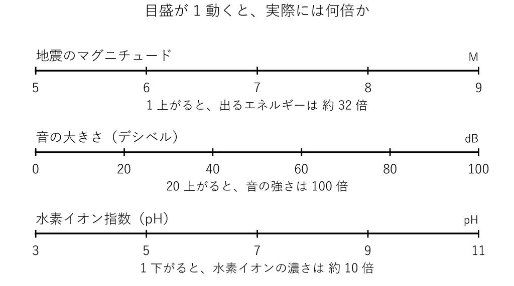

M が $1$ 増えると約 $32$ 倍（正確には $10^{1.5} \approx 31.6$）。dB も pH も同じ仕組み

## 比で感じる場面

**$100$ 円の値上げ**。$100$ 円の商品なら大事件、$10$ 万円の商品なら誤差

明るさや音

気づきやすさは  
元の強さに対する  
割合で決まる

経済のデータ

成長率や株価は  
比で見る

比で見る道具

$\log_{10}$ で測ると  
$10$ 倍ごとに $1$ 増える

この話は、この授業の後半で本題として戻ってくる

## まとめ

- 底の変換 $\log_a x = \frac{\log_b x}{\log_b a}$ の分母は古い底
- $\log_2 10 \approx 3.32$ $3$ と $4$ のあいだの数が、数になった
- 肩の文字は、両辺の対数をとって降ろす
- $23.4$ 年は小数まで許した値。年末払いなら切り上げ
- 対数目盛は、同じだけ動けば、いつも同じ倍率

**計算ドリル2 のブロック $4$・$5$・$6$** を解く → 第2回はここまで